# Most Dangerous and Costly Weather from 1950 to 2011

Clint Woody

2022-10-01

## Data Processing

1. The first step was loading and reading the data to include the .pdf from NOAA that describes the variables.

```r
if(!file.exists("./data")){dir.create("./data")}
url1<-"https://d396qusza40orc.cloudfront.net/repdata%2Fdata%2FStormData.csv.bz2"
url2<-"https://d396qusza40orc.cloudfront.net/repdata%2Fpeer2_doc%2Fpd01016005curr.pdf"
download.file(url1,"./data/StormData.csv.bz2",method="curl")
##download.file(url2,"./data/StormDataVar.pdf",method="curl")
storm_data<-read_csv("./data/StormData.csv.bz2")
```

```r
storm_data<-storm_data%>%select(c(2,7:8,23:28))%>%filter(PROPDMG>0|CROPDMG>0|
            FATALITIES>0|INJURIES>0)
```

3. Next I transformed the columns into usable classes, like Date class for the date and numeric for the cost. I also had to convert all the Damage estimates the same denomination.

```r
storm_data$BGN_DATE<-mdy_hms(storm_data$BGN_DATE)
storm_data$PROPDMG<- paste(storm_data$PROPDMG,storm_data$PROPDMGEXP,sep="")
storm_data$PROPDMG<- suppressWarnings(as.numeric(gsub("[Kk]","e3",
                                gsub("[Mm]","e6",
                                gsub("[Bb]","e9",
                                storm_data$PROPDMG)))))

storm_data$CROPDMG<- paste(storm_data$CROPDMG,storm_data$CROPDMGEXP,sep="")
storm_data$CROPDMG<- suppressWarnings(as.numeric(gsub("[Kk]","e3",
                                gsub("[Mm]","e6",
                                gsub("[Bb]","e9",
                                storm_data$CROPDMG)))))
```

4. From there I removed the two variables used to denote denomination in the damage variables. I also replaced the NA values with 0 in the two property and crop damage expense columns.

```r
storm_data<-subset(storm_data,select=(-c(PROPDMGEXP,CROPDMGEXP)))

storm_data$PROPDMG<-replace(storm_data$PROPDMG,is.na(storm_data$PROPDMG),0)
storm_data$CROPDMG<-replace(storm_data$CROPDMG,is.na(storm_data$CROPDMG),0)
```

5. Once I had a data set I could conduct calculations with I combined the two damage variables into one total damage variable labeled total_DMG. I added a column for just year year and I cleaned up the names of two other columns. I then grouped the data by year then event type. This allowed me to calculate the total fatalities, injuries, and cost by event per year.

```r
storm_data2<-storm_data%>%mutate(total_DMG=PROPDMG+CROPDMG,year=year(BGN_DATE))%>%
        rename("event_type"="EVTYPE","date"= "BGN_DATE")%>%
        group_by(year,event_type)%>%
        summarise(tot_fat_year=sum(FATALITIES),tot_inj_year=sum(INJURIES),
                  total_cost_year=(sum(total_DMG)/1000000000))
```

6. Next I made two separate tables, one focused on the health aspect and the other on economic cost. I further reduce the amount of data by only taking the top 10% of all observations in fatalities, injuries, and total cost. This captures 78% of all fatalities, 91% of all injuries, and 93% of all cost.

```r
top1DMG<-quantile(storm_data2$total_cost_year,prob=.90)
top1FAT<-quantile(storm_data2$tot_fat_year,prob=.90)
top1INJ<-quantile(storm_data2$tot_inj_year,prob=.90)

storm_data_health<-storm_data2%>%filter(tot_fat_year>top1FAT|tot_inj_year>top1INJ)
storm_data_cost<-storm_data2%>%filter(total_cost_year>top1DMG)
```

7. The last cleaning of data that I did was combined like type events into a single event to further condense the focus of the data. Below is an example how I did this bye changing the event name.

```r
storm_data_health$event_type<-
gsub("HEAVY SNOW|ICE STORM|BLIZZARD|EXTREME COLD|COLD/WIND CHILL|GLAZE",
     "WINTER STORM",
gsub("HIGH WIND|THUNDERSTORM WINDS|LIGHTNING|TSTM WIND|THUNDERSTORM WIND|HAIL",
                                     "THUNDERSTORM",
gsub("TROPICAL STORM|HURRICANE/TYPHOON|HURRICANE","HURRICANE/TS",
gsub("EXTREME HEAT|EXCESSIVE HEAT|HEAT WAVE", "HEAT",
gsub("FLASH FLOOD|FLOOD", "FLOODING",
gsub("RIP CURRENTS","RIP CURRENT",storm_data_health$event_type))))))
```

## Results

For the results I first looked at the lattice plots per event to see if anything stood out. To do this I needed to compute the total fatalities, injuries, and cost per event per year. Then I refined the data further into average per year per event and total per event.

# Health

Looking at health impacts with fatalities then injuries you can see below Tornado and Heat related events begin to stand out.

```r
total_fat_by_event<-storm_data_health%>%group_by(event_type)%>%
        summarise(total=sum(tot_fat_year))%>%arrange(desc(total))
average_fat_year<-storm_data_health%>%group_by(event_type)%>%
        summarise(average=mean(tot_fat_year))%>%arrange(desc(average))
total_inj_by_event<-storm_data_health%>%group_by(event_type)%>%
        summarise(total=sum(tot_inj_year))%>%arrange(desc(total))
average_inj_year<-storm_data_health%>%group_by(event_type)%>%
        summarise(average=mean(tot_inj_year))%>%arrange(desc(average))
```

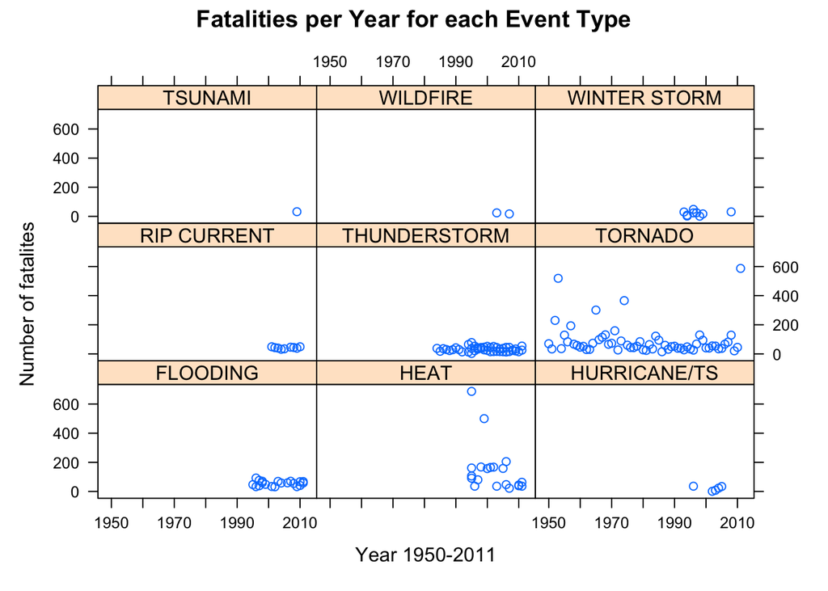

```r
xyplot(tot_fat_year~year|event_type,data=storm_data_health,
       xlab = "Year 1950-2011",ylab = "Number of fatalites",
       main = "Fatalities per Year for each Event Type")
```

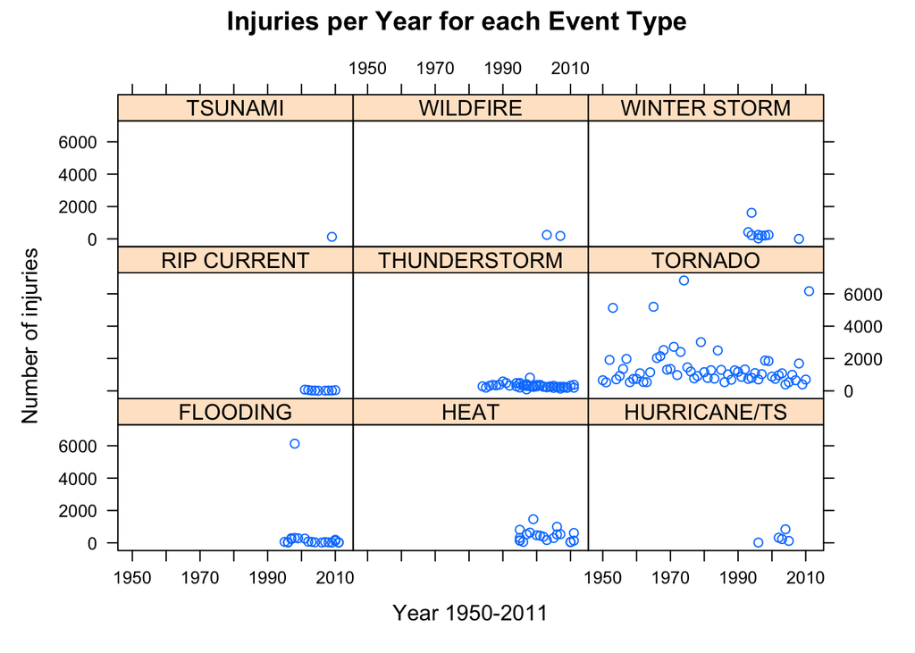

```r
xyplot(tot_inj_year~year|event_type,data=storm_data_health,
       xlab = "Year 1950-2011",ylab = "Number of injuries",
       main = "Injuries per Year for each Event Type")
```

```r
results_health<-merge(merge(total_fat_by_event,total_inj_by_event,1),
                      merge(average_fat_year,average_inj_year,1),1)
colnames(results_health)<-c("event","total_fatalities", "total_injuries",
                           "average_fatalities_year","average_injuries_year")
results_health<-arrange(results_health,desc(average_fatalities_year),desc(total_fat_by_event))
library(knitr)
kable(results_health, caption="Fatalities and Injuries due to Weather")
```

Fatalities and Injuries due to Weather

| event | total_fatalities | total_injuries | average_fatalities_year | average_injuries_year |
| --- | --- | --- | --- | --- |
| HEAT | 2968 | 8749 | 148.40000 | 437.45000 |
| TORNADO | 5633 | 91346 | 90.85484 | 1473.32258 |
| FLOODING | 1110 | 8251 | 55.50000 | 412.55000 |
| RIP CURRENT | 377 | 287 | 41.88889 | 31.88889 |
| THUNDERSTORM | 1483 | 14241 | 32.23913 | 309.58696 |
| TSUNAMI | 32 | 129 | 32.00000 | 129.00000 |
| WINTER STORM | 186 | 3199 | 20.66667 | 355.44444 |
| WILDFIRE | 41 | 434 | 20.50000 | 217.00000 |
| HURRICANE/TS | 102 | 1520 | 20.40000 | 304.00000 |

From the table when arranged in descending order by average fatalities a year it appears that **HEAT** is the most harmful to the population. However, TORNADO has the highest total fatalities with 5633.

# Cost

Looking at economic impacts with the cost of damages to property and crops combined you can see below Hurricanes and Flooding related events begin to stand out.

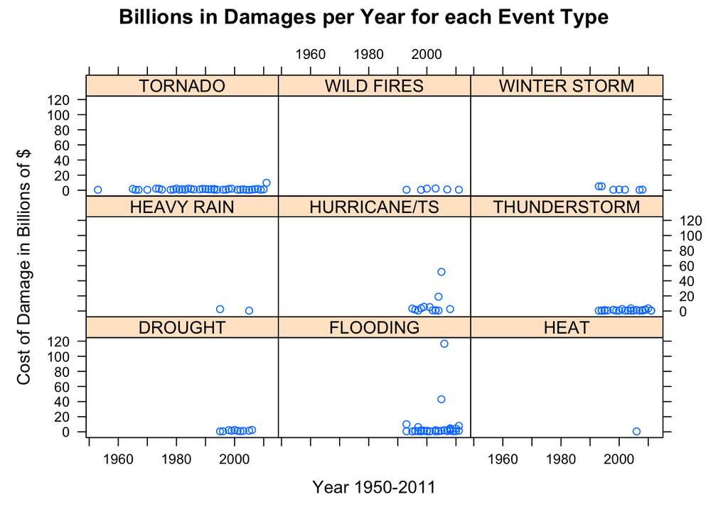

```r
total_cost_by_event<-storm_data_cost%>%group_by(event_type)%>%
        summarise(total=sum(total_cost_year))%>%arrange(desc(total))
average_cost_year<-storm_data_cost%>%group_by(event_type)%>%
        summarise(average=mean(total_cost_year))%>%arrange(desc(average))

xyplot(total_cost_year~year|event_type,data=storm_data_cost,
       xlab = "Year 1950-2011",ylab = "Cost of Damage in Billions of $",
       main = "Billions in Damages per Year for each Event Type")
```

```r
results_cost<-merge(total_cost_by_event,average_cost_year,1)
colnames(results_cost)<-c("event","total_cost", "average_cost_year")
results_cost<-arrange(results_cost,desc(average_cost_year))
library(knitr)
kable(results_cost, caption="Cost due to Damages in Billions of $")
```

Cost due to Damages in Billions of $

| event | total_cost | average_cost_year |
| --- | --- | --- |
| HURRICANE/TS | 96.589940 | 7.429995 |
| FLOODING | 222.399316 | 6.949979 |
| WINTER STORM | 13.842140 | 1.977449 |
| HEAVY RAIN | 2.992809 | 1.496404 |
| DROUGHT | 14.263487 | 1.426349 |
| TORNADO | 54.928781 | 1.373220 |
| WILD FIRES | 7.258208 | 1.209701 |
| THUNDERSTORM | 30.137165 | 1.116191 |
| HEAT | 0.492570 | 0.492570 |

From the table when arranged in descending order by average cost of damages per year in the billions it appears that **HURRICANE/TS** has the greatest economic consequences. However, FLOODING have the highest total cost of damages through the measured history with 222.3993158 Billion Dollars.